# Bifurcation diagrams

## Predict: how a bifurcation diagram is built

1/4

1

Fix the temperature

*T* = 3 to 18 °C

2

Predict next month

*O*<sub>*t*+1</sub> = 0.5 *O<sub>t</sub>* + 2.6 − 0.05 *T*

3

Feed it back, repeat

many months (paper: 1000)

4

Plot the late values

(paper: last 100), then change *T*

*O<sub>t</sub>*: omnivores in month *t*; *T*: temperature  
Illustrative equation, not fitted to data  
After Medeiros et al. 2025, *PNAS*

## Bifurcation diagram: the Lake Zurich example

2/4

1

Fix the phosphate

*p* = 0.02 to 0.07 mg/L

2

Predict next month

[figure not shown]

*G*<sub>*t*+1</sub> = *F*(*G*<sub>*t*…*t*−3</sub>, *p*, *T<sub>t</sub>*, *T*<sub>*t*−1</sub>)

3

Feed it back, repeat

1000 months

4

Plot the last 100

next *p* starts where this ended

*G<sub>t</sub>*: large green algae (ind/L) in month *t*; *F*: GP-EDM fitted to 1978–Oct 1987  
*T*: mean temperature of the calendar month  
Grey dots: observations  
Medeiros et al. 2025, *PNAS*: their data and code, re-run

## Lake Zurich: green algae, phosphate and the shift

3/4

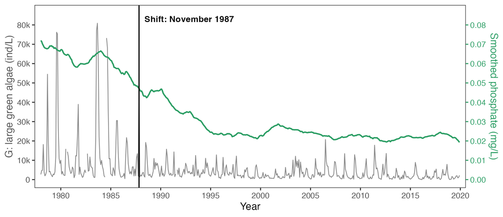

Grey: monthly large green algae (*G*); green: phosphate, 25-month centred mean; line: change point, the split of the series with the smallest sum of squares within the two parts  
Data and shift: Medeiros et al. 2025, *PNAS* (Fig. 5A)

## Bifurcation diagram: uncertainty about *f*

4/4

*f* | data ~ GP(*μ*, *S*)

*μ*(**z**) = **k**(**z**)<sup>⊤</sup>(**K** + *v***I**)<sup>−1</sup>**y**

*S*(**z**, **z**′) = *C*(**z**, **z**′) − **k**(**z**)<sup>⊤</sup>(**K** + *v***I**)<sup>−1</sup>**k**(**z**′)

a) What happens to G if *f* = *μ*? (Medeiros et al. 2025)

b) How high does G get across functions *f* ~ GP(*μ*, *S*)?

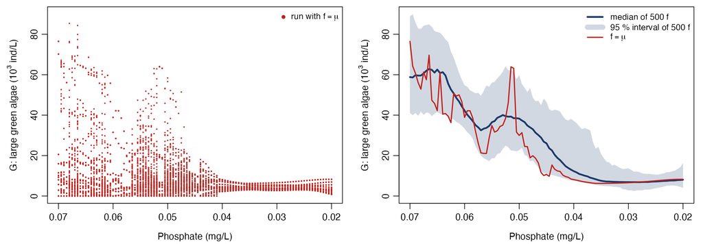